# Decision Trees

## Introduction

To enhance the analysis done in the Naïve Bayes section we will now apply a new machine learning algorithm to the Electric Vehicles Characteristics dataset. In this section we will also introduce Decision Trees, describe the types, advantages and disadvantages, and later dive into the application and analysis.

For this analysis we will use Python and below we have the list of libraries imported and the functions created:

**Libraries**

```python
# Import Data
import pandas as pd

# Data Cleaning
import numpy as np

# Visualization
import seaborn as sns
import matplotlib.pyplot as plt

# Split Dataset
from sklearn.model_selection import train_test_split

# Random Classifier
from collections import Counter

# Sklearn Decision Tree Model
from sklearn import tree

# Show Results
from sklearn.metrics import confusion_matrix, ConfusionMatrixDisplay

# Metrics
from sklearn.metrics import accuracy_score
from sklearn.metrics import precision_recall_fscore_support
from sklearn.metrics import precision_score
from sklearn.metrics import recall_score
```

**Function: random_classifier()**

```python
## RANDOM CLASSIFIER
def random_classifier(y_data):
    ypred=[];
    max_label=np.max(y_data); #print(max_label)
    for i in range(0,len(y_data)):
        ypred.append(int(np.floor((max_label+1)*np.random.uniform(0,1))))

    print("-----RANDOM CLASSIFIER-----")
    print("count of prediction:",Counter(ypred).values()) # counts the elements' frequency
    print("probability of prediction:",np.fromiter(Counter(ypred).values(), dtype=float)/len(y_data)) # counts the elements' frequency
    print("accuracy",accuracy_score(y_data, ypred))
    print("percision, recall, fscore,",precision_recall_fscore_support(y_data, ypred))
```

**Function: confusion_plot()**

```python
def confusion_plot(actual, pred):

    matrix = confusion_matrix(actual, pred)

    TP = matrix[0,0]
    FN = matrix[0,1]
    FP = matrix[1,0]
    TN = matrix[1,1]

    ACCURACY = (TP+TN)/(TP+FP+FN+TN)
    NEGATIVE_RECALL = TN/(TN+FP)
    NEGATIVE_PRECISION = TN/(TN+FN)
    POSITIVE_RECALL = TP/(TP+FN)
    POSITIVE_PRECISION = TP/(TP+FP)

    print('ACCURACY: ', ACCURACY)
    print('NEGATIVE RECALL (Y=0): ', NEGATIVE_RECALL)
    print('NEGATIVE PRECISION (Y=0): ', NEGATIVE_PRECISION)
    print('POSITIVE RECALL (Y=1): ', POSITIVE_RECALL)
    print('POSITIVE PRECISION (Y=1): ', POSITIVE_PRECISION)

    print(matrix)

    cm = confusion_matrix(actual, pred)
    disp = ConfusionMatrixDisplay(confusion_matrix=cm)
    disp.plot()
```

**Function: plot_tree()**

```python
def plot_tree(model, X, Y, labels):
    model_X_Y = model.fit(X, Y)

    fig = plt.figure(figsize=(25,20))
    _ = tree.plot_tree(model_X_Y,
                        feature_names=X.columns,
                        class_names=labels,
                        filled=True)

    plt.show()
```

## Methods

In Machine Learning, decision trees are classified as non-parametric supervised learning method used for both classification and regression models.

The goal of decision trees is to create a model that predicts the output value of the target variables based on different set of rules. This can be better understood as a set of questions where the first one, the root node, is a very general questions, and based on the answer the trajectory to make the next question. After several questions you can get to the final value.

To go from one inner node to another, there may be two possible paths, which we identify as binary split as it divides values into two subsets, or more tan two possible paths, which we identify as multi way split as it uses as many partitions as distinct values.

There are different types of decision trees, but in this analysis we will focus in binary classifier, where the output of each node is true or false.

Decision trees have several advantages such as that they are simple to understand and easy to interpret. This is due to the visualization of the tree that can be created in order to understand the logic and the conditions behind it. It also required minimal data preparation compared to other models. As it was explained before, they can handle both numerical and categorical data and combine them in a way to handle multi-outut problems.

One of the main disadvantages of the decision trees is that they tend to overfit, but there are several techniques that can be applied to reduce this, such as pruning or setting a maximum depth. The predictions done by the decision trees are local, this means that if we want to extrapolate to new values, they might not perform well. Lastly, we need to consider that if the dataset is not well balanced, the performance might be poor too because the results will tend to be biased.

### Class distribution

The first step is to import the data we will be using for the analysis. As we can observe, the dataset contains both numeric and categoric variables which we will later drop based on the analysis. The original dataset contains 10 columns and 360 rows.

#### Original Data

| Brand | CarName | Battery | Efficiency | FastCharge | Price | Range | TopSpeed | Acceleration | Continent |
| --- | --- | --- | --- | --- | --- | --- | --- | --- | --- |
| Abarth | Abarth 500e Hatchback | 37.8 | 168 | 370 | 37990 | 225 | 155 | 7.0 | Europe |
| Abarth | Abarth 500e Convertible | 37.8 | 168 | 370 | 40990 | 225 | 155 | 7.0 | Europe |
| Aiways | Aiways U6 | 60.0 | 171 | 430 | 47588 | 350 | 160 | 7.0 | Europe |
| Aiways | Aiways U5 | 60.0 | 190 | 380 | 39563 | 315 | 150 | 7.5 | Europe |
| Audi | Audi Q8 e-tron Sportback 50 quattro | 89.0 | 200 | 690 | 76650 | 445 | 200 | 6.0 | Europe |

```
(360, 10)
```

#### Data Cleaning

As it was mentioned in previous sections, there are some cases where we need to apply additional data cleaning steps to satisfy the models’ requirements. In this case we need to filter out the rows that contain NAs. After cleaning the data, we can see that the number of rows was reduced to 307 data points.

**{python}**

```python
df_vehicles = df_vehicles.dropna()

df_vehicles.head(5).to_csv('../../data/02-visualization-data/df_vehicles_4.csv', index=False)
```

| Brand | CarName | Battery | Efficiency | FastCharge | Price | Range | TopSpeed | Acceleration | Continent |
| --- | --- | --- | --- | --- | --- | --- | --- | --- | --- |
| Abarth | Abarth 500e Hatchback | 37.8 | 168 | 370 | 37990 | 225 | 155 | 7.0 | Europe |
| Abarth | Abarth 500e Convertible | 37.8 | 168 | 370 | 40990 | 225 | 155 | 7.0 | Europe |
| Aiways | Aiways U6 | 60.0 | 171 | 430 | 47588 | 350 | 160 | 7.0 | Europe |
| Aiways | Aiways U5 | 60.0 | 190 | 380 | 39563 | 315 | 150 | 7.5 | Europe |
| Audi | Audi Q8 e-tron Sportback 50 quattro | 89.0 | 200 | 690 | 76650 | 445 | 200 | 6.0 | Europe |

```
(307, 10)
```

#### Data Exploration

The next step is to divide the target column from the original data set. In this case, the target column is the continent where the car was manufactured. The numeric columns are the features of the analysis used to construct the decision tree.

We can see that there are more records for Europe compared to North America and Asia. This can be a limitation for the decision tree because the classes are unbalanced. Considering that we don’t have many records, we will not downsample the data because we will lose a lot of data points.

**{python}**

```python
labels = df_vehicles['Continent'].unique()

df_vehicles['target'] = df_vehicles['Continent']

length_0 = len(df_vehicles[df_vehicles['target'] == 'North America'])
length_1 = len(df_vehicles[df_vehicles['target'] == 'Europe'])
length_2 = len(df_vehicles[df_vehicles['target'] == 'Asia'])

total = df_vehicles.shape[0]

print('\n', 'Number of points with target = North America: ', length_0, length_0/total, '\n', 'Number of points with target = Europe: ', length_1, length_1/total, '\n', 'Number of points with target = Asia: ', length_2, length_2/total)
```

```
 Number of points with target = North America:  38 0.1237785016286645
 Number of points with target = Europe:  195 0.6351791530944625
 Number of points with target = Asia:  74 0.24104234527687296
```

To explore the data we are going to use, we created a correlation plot between the variables. We can see the Pearson correlation between all the variables. There are some that are highly positively correlated and some that don’t have any correlation at all.

**{python}**

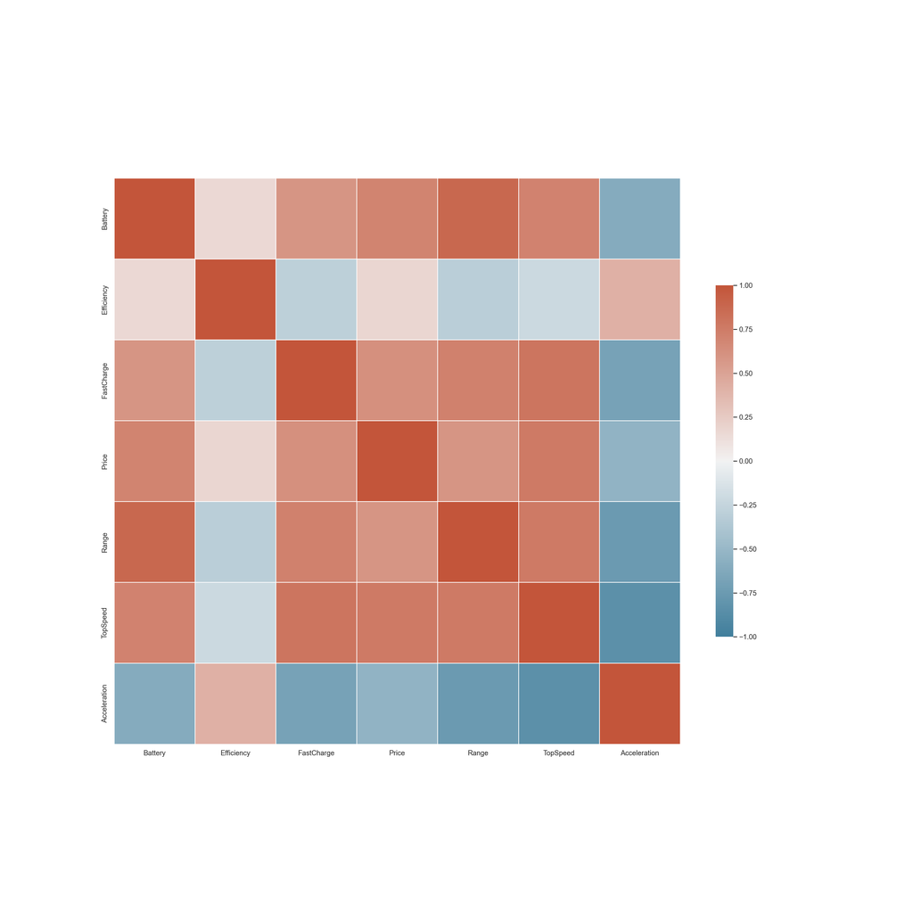

```python
target_column = 'target'

Y = df_vehicles[target_column]
Y = pd.Categorical(df_vehicles['Continent']).codes

X = df_vehicles[['Battery', 'Efficiency', 'FastCharge', 'Price', 'Range', 'TopSpeed', 'Acceleration']]

df_vehicles = df_vehicles[['Battery', 'Efficiency', 'FastCharge', 'Price', 'Range', 'TopSpeed', 'Acceleration']]

corr = df_vehicles.corr()

sns.set_theme(style="white")
f, ax = plt.subplots(figsize=(20, 20))
cmap = sns.diverging_palette(230, 20, as_cmap=True)

sns.heatmap(corr,  cmap=cmap, vmin=-1, vmax=1, center=0,
        square=True, linewidths=.5, cbar_kws={"shrink": .5})

plt.show()
```

## Random Classifier Model

Before building a decision tree model, we decided to test a baseline model to compare results in the next steps. The baseline model that will be used is a random classifier, since there are no criteria for assigning labels. The goal of comparing the random classifier with the decision tree is to see if the performance of our model is better than the performance of assigning a random label.

We can see that we get an accuracy of about 0.3, which is very low.

**{python}**

```python
X_array = X
Y_array = Y

x_train, x_test, y_train, y_test = train_test_split(X_array, Y_array, test_size=0.2, random_state=0)
```

[output not shown]

[output not shown]

## Decision Tree Model

Now that we have the random classifier model, we can build the decision tree model. To evaluate the results, we use the confusion matrix function that we created at the beginning of this section.

For the training set, we get very good results because the accuracy is equal to 1, so the other performance metrics, positive and negative recalls and precisions, are also equal to 1. For the test set, we get an accuracy of about 0.83, which is higher compared to the random classifier and we consider it a good performance for this model.

Looking at the decision tree, we can see that there is a high number of branches and a high depth. So, the next step is to apply model tuning techniques in order to get a simpler version without sacrificing the performance.

**Train Results**

```
ACCURACY:  1.0
NEGATIVE RECALL (Y=0):  1.0
NEGATIVE PRECISION (Y=0):  1.0
POSITIVE RECALL (Y=1):  1.0
POSITIVE PRECISION (Y=1):  1.0
[[ 58   0   0]
 [  0 154   0]
 [  0   0  33]]
```

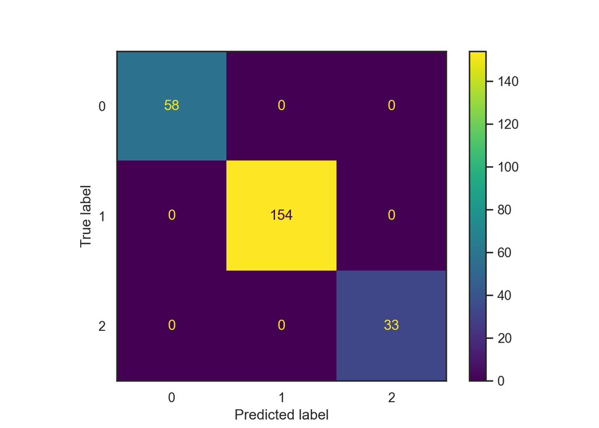

**Test Results**

```
ACCURACY:  0.8367346938775511
NEGATIVE RECALL (Y=0):  0.8484848484848485
NEGATIVE PRECISION (Y=0):  0.9032258064516129
POSITIVE RECALL (Y=1):  0.8125
POSITIVE PRECISION (Y=1):  0.7222222222222222
[[13  3  0]
 [ 5 28  8]
 [ 0  1  4]]
```

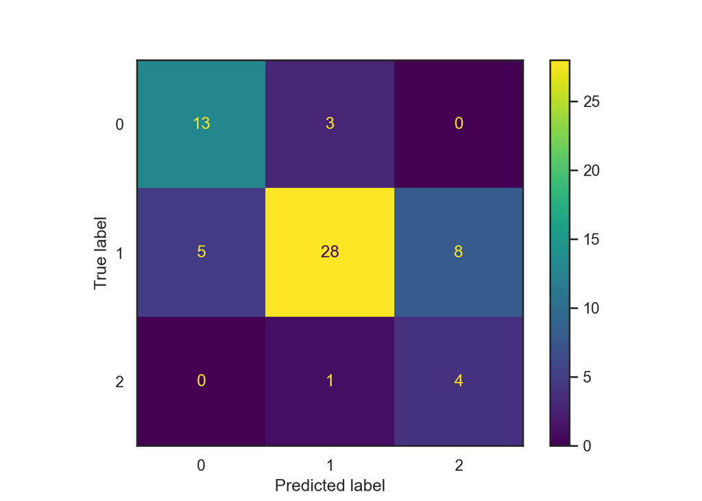

**Tree Plot**

**{python}**

```python
plot_tree(tree.DecisionTreeClassifier(), x_train, y_train, labels)
```

[figure not shown]

## Model tuning:

To get the best decision tree model, we can tune the hyperparameters of the model. There are two types of hyperparameters that can be tuned. First, the min_samples, which is the minimum number of samples needed to split an internal node. The second is the max_depth, which is the maximum depth of the tree.

Below, we apply the hypertuning process to the max_depth parameter. Considering the low number of data points for the analysis the test and train metric values vary through the number of layers in decision tree. Therefore, for this analysis we choose a maximum depth equal to 5.

**{python}**

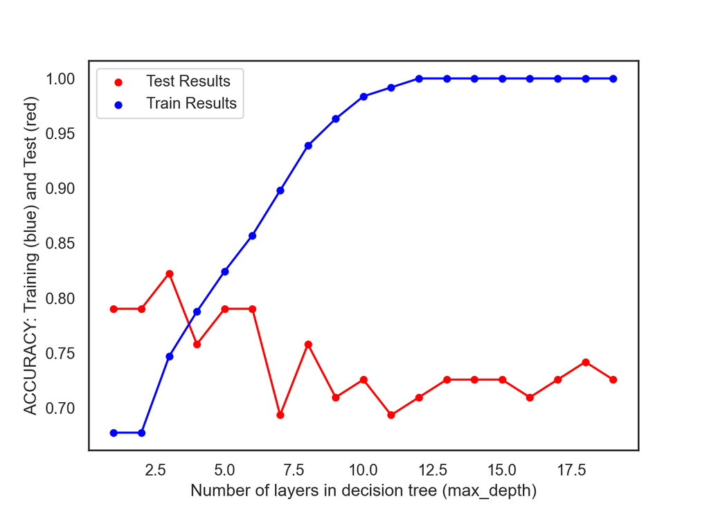

```python
test_results=[]
train_results=[]

for num_layer in range(1,20):
    model = tree.DecisionTreeClassifier(max_depth=num_layer)
    model = model.fit(x_train,y_train)

    yp_train=model.predict(x_train)
    yp_test=model.predict(x_test)

    # print(y_pred.shape)
    test_results.append([num_layer,accuracy_score(y_test, yp_test),recall_score(y_test, yp_test,average='micro')])
    train_results.append([num_layer,accuracy_score(y_train, yp_train),recall_score(y_train, yp_train,average='micro')])

test_results = pd.DataFrame(test_results, columns= ("num_layer", "accuracy_score", "recall_score"))
train_results = pd.DataFrame(train_results, columns= ("num_layer", "accuracy_score", "recall_score"))

# ACCURACY

sns.scatterplot(data=test_results, x='num_layer', y='accuracy_score', label='Test Results', color='red')
sns.lineplot(data=test_results, x='num_layer', y='accuracy_score', color='red')

sns.scatterplot(data=train_results, x='num_layer', y='accuracy_score', label='Train Results', color='blue')
sns.lineplot(data=train_results, x='num_layer', y='accuracy_score', color='blue')

plt.xlabel('Number of layers in decision tree (max_depth)')
plt.ylabel('ACCURACY: Training (blue) and Test (red)')

plt.show()
```

**{python}**

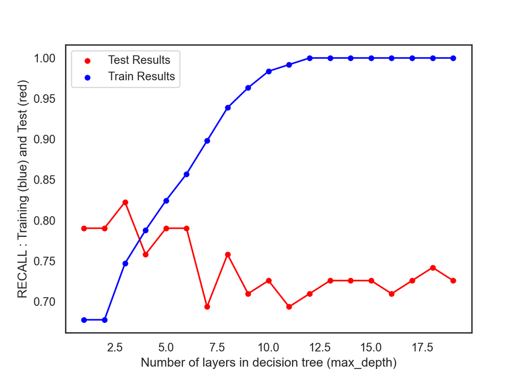

```python
# RECALL

sns.scatterplot(data=test_results, x='num_layer', y='recall_score', label='Test Results', color='red')
sns.lineplot(data=test_results, x='num_layer', y='recall_score', color='red')

sns.scatterplot(data=train_results, x='num_layer', y='recall_score', label='Train Results', color='blue')
sns.lineplot(data=train_results, x='num_layer', y='recall_score', color='blue')

plt.xlabel('Number of layers in decision tree (max_depth)')
plt.ylabel('RECALL : Training (blue) and Test (red)')

plt.show()
```

## Final results

After running the final results, we can see that the shape of the decision tree has changed and the performance metrics have also changed. We can observe an accuracy of 0.86 for the training set and 0.92 for the test set. The accuracy for the test set has increased and the training set has decreased. Considering that both values are high, we will keep the model and conclude that we have obtained very good performance.

**{python}**

```python
best_max_depth = 5

model = tree.DecisionTreeClassifier(max_depth=best_max_depth)
model = model.fit(x_train,y_train)

yp_train=model.predict(x_train)
yp_test=model.predict(x_test)

print("------TRAINING------")
```

```
------TRAINING------
```

**{python}**

```python
confusion_plot(y_train,yp_train)
```

```
ACCURACY:  0.8647342995169082
NEGATIVE RECALL (Y=0):  0.9473684210526315
NEGATIVE PRECISION (Y=0):  0.8780487804878049
POSITIVE RECALL (Y=1):  0.6363636363636364
POSITIVE PRECISION (Y=1):  0.813953488372093
[[ 35  20   3]
 [  8 144   2]
 [  0  10  23]]
```

**{python}**

```python
print("------TEST------")
```

```
------TEST------
```

**{python}**

```
ACCURACY:  0.9183673469387755
NEGATIVE RECALL (Y=0):  1.0
NEGATIVE PRECISION (Y=0):  0.8918918918918919
POSITIVE RECALL (Y=1):  0.75
POSITIVE PRECISION (Y=1):  1.0
[[12  4  0]
 [ 0 33  8]
 [ 0  0  5]]
```

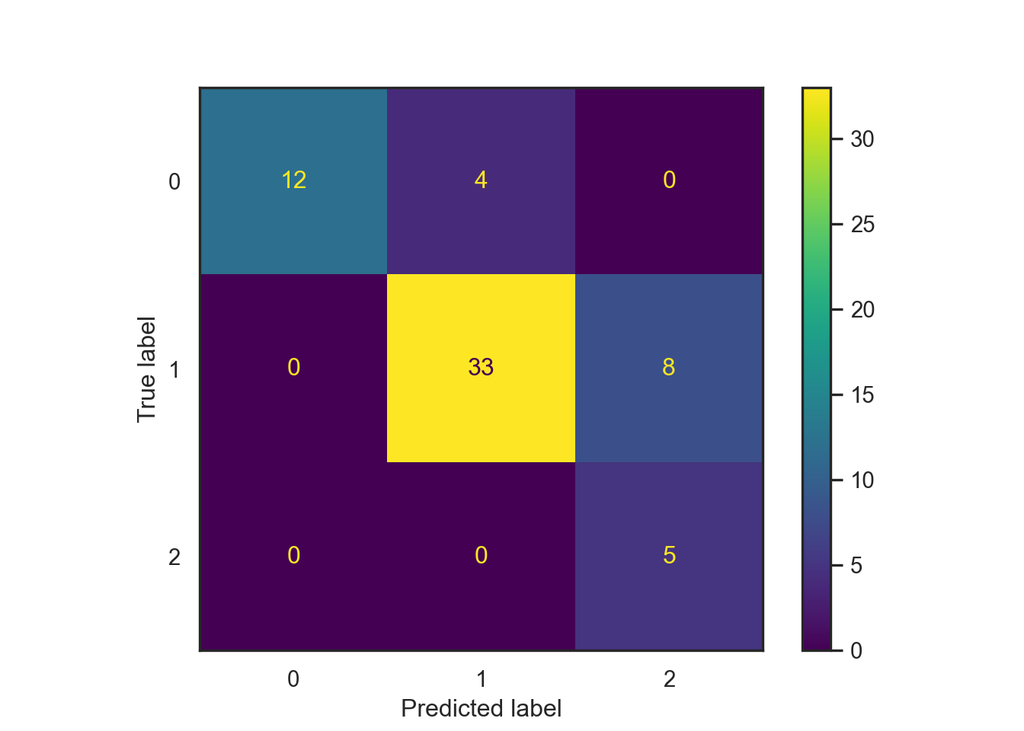

```python
confusion_plot(y_test,yp_test)
```

**{python}**

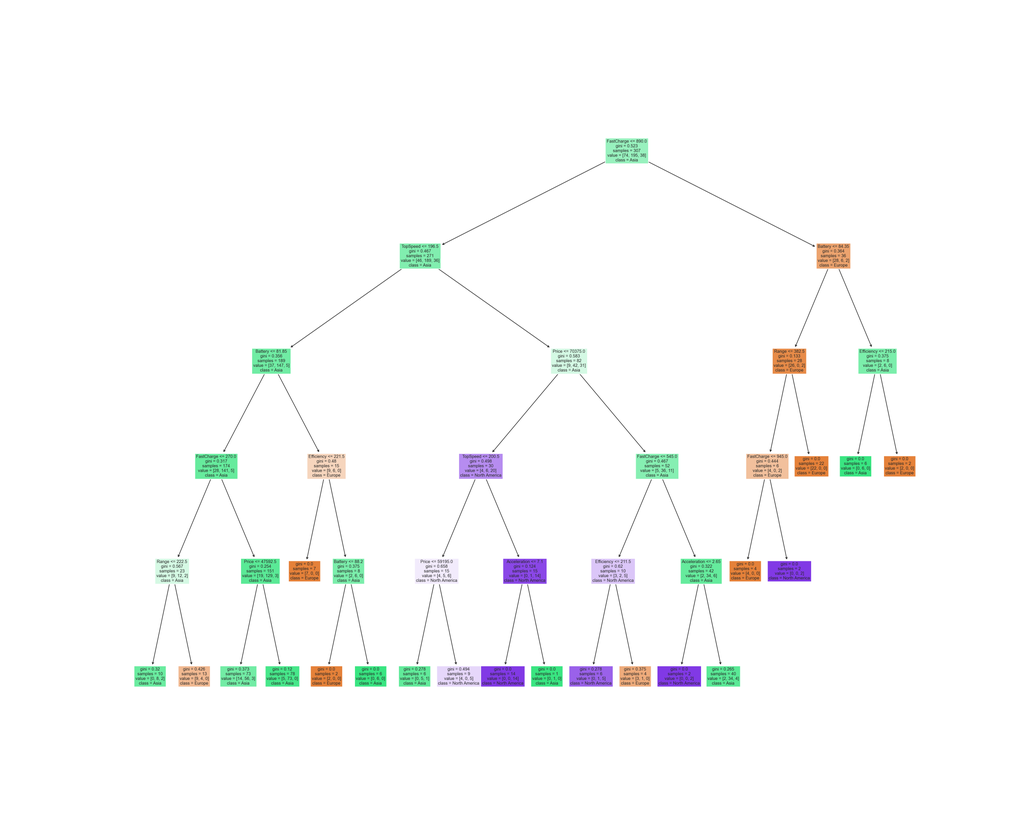

[figure not shown]

```python
plot_tree(model,X,Y, labels)
```

## Conclusions

The conclusions we can draw from this analysis are very similar to those of Naive Bayes. Based on the results obtained, we can see that the values for the analyzed features are useful to determine in which continent each car was manufactured. Considering the small number of data points, it would be useful in the future to include additional data points to make the analysis more balanced. It would also be useful to add another target label to understand, for example, if we can target the country where the electric vehicles are manufactured.

Compared to the Naive Bayes model, we can see that a big advantage of decision trees is that they are easy to interpret and understand the decisions made to arrive at the final value.